# SDMs: Honours Guide

### Principal Component Analysis - explore predictor variables

Let’s have a look at the contribution of each variable to the model.

```r
presPoints = readRDS("data/presPoints.rds")
climate.df = dplyr::select(presPoints, !c(species, decimalLatitude, decimalLongitude))
head(climate.df)

# Create new column names
new_names = c(paste0("bio_", c("1", "2", "5", "9", "12", "15", "19")), "elev")

# Set the new column names
colnames(climate.df) = new_names
head(climate.df)
```

🟢 Run a PCA on the `climate.df` data frame using the `prcomp()` function, and then access the loadings using the `rotation` attribute of `pca_res` (hint: use the dollar sign to access attributes -> `$`).

```r
pca_res = # RUN PCA HERE
summary(pca_res)

loadings = # ACCESS LOADINGS
loadings

PCA = factoextra::fviz_pca_var(pca_res,
                  col.var = "contrib", # Color by contributions to the PC
                  gradient.cols = c("blue", "gold", "red"),
                  repel = TRUE) + theme_classic(); PCA

# Contributions of variables to PC1
a = factoextra::fviz_contrib(pca_res, choice = "var", axes = 1)
# Contributions of variables to PC2
b = factoextra::fviz_contrib(pca_res, choice = "var", axes = 2)
pca_contribs = gridExtra::grid.arrange(a, b, ncol=2, top='Contribution of the variables to the first two PCs')

#ggsave(file = "figs/pca_contributions.png", pca_contribs, dpi = 350, height = 5, width = 10)
#ggsave(file = "figs/pca.png", PCA, dpi = 350, height = 5, width = 6)
```

Let’s plot the PCA again, but now let’s have a look at whether there is any difference between the climate in the native versus the invaded range. First, we’ll create a new data frame from our presence points, and add a grouping column called `range`. We can use an `ifelse` statement here to assign the word “native” or “nonnative” to each GPS record depending on its longitude:

```r
presPoints.new = presPoints %>%
dplyr::mutate(range = dplyr::if_else(decimalLongitude > 60, "native", "nonnative"))

head(presPoints.new)

head(climate.df)

# extract all PC1 and PC2 values
pca_res_df = pca_res$x %>%
  as.data.frame() %>%
  # keep only PC1 and PC2
  dplyr::select(c(PC1, PC2))

# add the range grouping column
pca_res_df$range = presPoints.new$range

pca_plot = pca_res_df %>%
  ggplot(aes(PC1, PC2, color = range)) +
  geom_point(size = 1.5, alpha = 0.5) +
  scale_color_manual(
    values = c(nonnative = "darkred", native = "forestgreen")
  ) +
  xlab("PC1 (32%)") +
  ylab("PC2 (31%)") +
  labs(color = "Range",
       title = "ACP niche conservatism") +
  # add lines through the origin
  geom_hline(yintercept = 0, linetype = "dashed", color = "gray") +
  geom_vline(xintercept = 0, linetype = "dashed", color = "gray") +
  theme_classic()

pca_plot

# another approach, adding ellipses
factoextra::fviz_pca_ind(pca_res, geom = "point",
                         col.ind = presPoints.new$range,
                         palette = c("forestgreen",  "darkred"),
                         legend.title = "Range", alpha.ind = 0.5,
                         addEllipses = TRUE) +
                         scale_shape_manual(values=c(19,17))

# run t-tests to see whether there is a difference between native vs non-native points on PC1, and PC2
t.test(PC1 ~ range, data = pca_res_df)
t.test(PC2 ~ range, data = pca_res_df)

# looks like there is a difference on PC1, but not PC2

# check the distribution of the data
hist(pca_res_df$PC1)
hist(pca_res_df$PC2)
```

Run a Schoener’s D test to check niche overlap:

```r
pca_native = pca_res_df %>%
  dplyr::filter(range == "native") %>%
  dplyr::select(PC1, PC2)

pca_nonnative = pca_res_df %>%
  dplyr::filter(range == "nonnative") %>%
  dplyr::select(PC1, PC2)

all_pca = pca_res_df %>%
  dplyr::select(PC1, PC2)

grid_native = ecospat::ecospat.grid.clim.dyn(glob = all_pca, glob1 = pca_native, sp = pca_native, R = 100)
grid_nonnative = ecospat::ecospat.grid.clim.dyn(glob = all_pca, glob1 = pca_nonnative, sp = pca_nonnative, R = 100)

# Schoener's D
schoener_d = ecospat::ecospat.niche.overlap(grid_native, grid_nonnative, cor = FALSE)$D

# Print the overlap value
print(schoener_d)

ecospat::ecospat.plot.niche.dyn(grid_native, grid_nonnative, quant = 0.1, interest = 2, title = "Niche Overlap", name.axis1 = "PC1", name.axis2 = "PC2", col.unf = "black", col.exp = "darkred", col.stab = "lightgreen", colZ1 = "darkgreen", colZ2 = "red", transparency = 60)
```

**Schoener’s D interpretation:**

0.0 → No overlap (completely distinct ecological niches)  
0.5 → Moderate overlap (some shared environmental space)  
1.0 → Complete overlap (both groups use the same niche)

Let’s make some box-plots, showing each bioclimate variable (and elevation) across the native vs non-native range:

```r
presPoints_long = presPoints.new %>%
  tidyr::pivot_longer(cols = starts_with("wc2.1_2.5m_bio") | "wc2.1_2.5m_elev",  # Include elevation
               names_to = "bio_variable",
               values_to = "value")

new_names = c(paste0("bio_", c("1", "2", "5", "9", "12", "15", "19")), "elev")

# Reorder and rename the bio_variable levels
presPoints_long$bio_variable = factor(presPoints_long$bio_variable,
                                       levels = c("wc2.1_2.5m_bio_1", "wc2.1_2.5m_bio_2", "wc2.1_2.5m_bio_5",
                                                  "wc2.1_2.5m_bio_9", "wc2.1_2.5m_bio_12", "wc2.1_2.5m_bio_15",
                                                  "wc2.1_2.5m_bio_19", "wc2.1_2.5m_elev"),
                                       labels = new_names)

# Plot boxplots for native vs non-native groups, faceted by bio variables and including elevation
range.boxes = ggplot(presPoints_long, aes(x = range, y = value, fill = range)) +
  geom_boxplot(alpha = 0.5) +
  scale_fill_manual(values = c(nonnative = "darkred", native = "forestgreen")) +
  facet_wrap(~ bio_variable, scales = "free_y") +  # Facet by bio variable with independent y-scales
  labs(x = "Range (Native vs Non-native)", y = "Value",
       title = "ACP Bioclimatic Variables and Elevation by Range")

range.boxes
```

## Create the MaxEnt model

We are finally ready to create a MaxEnt model, which we can project onto any geographic area we like. Keep in mind though the distinction between model interpolation and extrapolation, and the reliability of the model considering the range of values that it was trained on.

Our best model was H3, and so we will set `'betamultiplier=3.0'` and `'hinge=true'`.

### Fit the MaxEnt model

```r
presPoints = readRDS("data/presPoints.rds")
backPoints = readRDS("data/backPoints.rds")
reduced_preds = terra::rast("data/reduced_preds.tif")

# bind the presence and absence data together into one data frame
maxent_data = dplyr::bind_rows(presPoints, backPoints) %>%
  dplyr::select(-c(species, decimalLatitude, decimalLongitude))
rownames(maxent_data) = NULL
head(maxent_data)
nrow(maxent_data)

# Create a vector containing 0 (indicating background points) and 1 (indicating presence points)
maxent_vector = c(
  replicate(nrow(presPoints), "1"),
  replicate(nrow(backPoints), "0")
)

# FIT MAXENT MODEL
maxentModel1 = dismo::maxent(
  x = maxent_data,
  p = maxent_vector,
  path = here::here("models/maxent_H3/"),
  replicates = 10,
  args = c(
    # Insert the optimal RM value here
    'betamultiplier=3.0',
    # Turn these on/off to change FC combinations
    # - To only use quadratic features, turn all to false except quadratic
    'linear=false',
    'quadratic=false',
    'product=false',
    'threshold=false',
    'hinge=true',
    # Don't change anything from here down
    'threads=2',
    'doclamp=true',
    'fadebyclamping=true',
    'responsecurves=true',
    'jackknife=true',
    'askoverwrite=false',
    'responsecurves=true',
    'writemess=true',
    'writeplotdata=true',
    'writebackgroundpredictions=true'
  )
)

response_data = dismo::response(maxentModel1, expand = TRUE)

# get the response data for each variable
bio1.response = as.data.frame(dismo::response(maxentModel1, var = "wc2.1_2.5m_bio_1"))  %>%
  dplyr::mutate(name = "bio1") %>% dplyr::rename(value = V1)

bio2.response = as.data.frame(dismo::response(maxentModel1, var = "wc2.1_2.5m_bio_2"))%>%
  dplyr::mutate(name = "bio2") %>% dplyr::rename(value = V1)

bio5.response = as.data.frame(dismo::response(maxentModel1, var = "wc2.1_2.5m_bio_5"))%>%
  dplyr::mutate(name = "bio5") %>% dplyr::rename(value = V1)

bio9.response = as.data.frame(dismo::response(maxentModel1, var = "wc2.1_2.5m_bio_9")) %>%
  dplyr::mutate(name = "bio9") %>% dplyr::rename(value = V1)

bio12.response = as.data.frame(dismo::response(maxentModel1, var = "wc2.1_2.5m_bio_12"))%>%
  dplyr::mutate(name = "bio12") %>% dplyr::rename(value = V1)

bio15.response = as.data.frame(dismo::response(maxentModel1, var = "wc2.1_2.5m_bio_15"))%>%
  dplyr::mutate(name = "bio15") %>% dplyr::rename(value = V1)

bio19.response = as.data.frame(dismo::response(maxentModel1, var = "wc2.1_2.5m_bio_19"))%>%
  dplyr::mutate(name = "bio19") %>% dplyr::rename(value = V1)

elev.response = as.data.frame(dismo::response(maxentModel1, var = "wc2.1_2.5m_elev"))%>%
  dplyr::mutate(name = "elevation") %>% dplyr::rename(value = V1)

# join everything together
bioresponses = rbind(bio1.response, bio2.response, bio5.response, bio9.response, bio12.response, bio15.response,
                     bio19.response, elev.response) %>%
  dplyr::mutate(name = factor(name, levels = c("bio1", "bio2", "bio5", "bio9", "bio12", "bio15", "bio19", "elevation")))

# make a custom ggplot
response.plots = ggplot(bioresponses, aes(x = value, y = p)) +
  geom_line(linewidth = 1, colour = "darkgrey") +
  facet_wrap(~name, scales = "free") +
  labs(x = "Predictor Value", y = "Predicted Response",
       title = "Maxent Response Curves")

response.plots
```

Examine the model output files, particularly the response curves for each variable, and the importance of each variable to the model (contribution scores). Here, bio 1, 12, and 19 appear to have the greatest influence on the model. The average AUC result is 0.83 (i.e. 83% accuracy on the training data).

### Set up the prediction area

Now that we have created our MaxEnt model, we need to decide where we want to project it, and then create raster layers for that area using our set of predictor variables. Below, we will create raster layers for the African continent:

```r
if(!dir.exists("africa_env_layers")){
  dir.create("africa_env_layers")
}

if(!dir.exists("africa_env_layers/current")){
  dir.create("africa_env_layers/current")
}

# get the raster for Africa
africa_ext = rnaturalearth::ne_countries(scale = "medium", returnclass = "sf") %>%
  dplyr::filter(continent == "Africa")

# read in our predictors again
reduced_preds = terra::rast("data/reduced_preds.tif")

# crop rasters
africa_env_layers = raster::crop(reduced_preds, raster::extent(africa_ext))

# set the CRS
crs(africa_env_layers) = "EPSG:4326"

terra::writeRaster(africa_env_layers, "africa_env_layers/africa_env_layers.tif", overwrite=TRUE)
```

```r
terra::rast("africa_env_layers/africa_env_layers.tif") %>% plot()
```

```r
directory.current = "africa_env_layers/current/"

# Loop over each climate variable and save it with the correct name
# write these rasters to file
for (p in names(reduced_preds)){
  raster::writeRaster(
    africa_env_layers[[which(names(africa_env_layers) %in% p)]],
    filename = paste0(directory.current, p, ".grd"),
    bylayer = TRUE,
    overwrite = TRUE,
    format = "raster",
    bandorder = 'BIL'
  )
}
```

## Project the MaxEnt model

Finally we can do some projecting!

```r
if(!dir.exists("raster_projections")){
  dir.create("raster_projections")
}

africa_env_layers = terra::rast("africa_env_layers/africa_env_layers.tif")

# get the raster for Africa
africa_ext = rnaturalearth::ne_countries(scale = "medium", returnclass = "sf") %>%
  dplyr::filter(continent == "Africa")

africa_ext = sf::st_set_crs(africa_ext, 4326)

# use the model to predict climate suitability for Africa
predict_maxent_africa = terra::predict(maxentModel1, africa_env_layers)
predict_maxent_africa = terra::mask(predict_maxent_africa, africa_ext)

terra::plot(predict_maxent_africa)

terra::writeRaster(predict_maxent_africa, "raster_projections/maxent_projection_africa.tif",
                   overwrite = TRUE)

presPoints = readRDS("data/presPoints.rds")

# filter to get points just in Africa
species_afr = presPoints %>%
  dplyr::filter(decimalLongitude > -26, decimalLatitude < 55, decimalLatitude > -48, decimalLatitude < 40)

africa = ggplot() +
  # Plot MaxEnt prediction raster
  tidyterra::geom_spatraster(
    data = predict_maxent_africa,
    maxcell = 5e+7         # maxcell = Inf
  ) +
  # Control raster colour and legend
 tidyterra::scale_fill_whitebox_c(
    palette = "muted",
    breaks = seq(0, 1, 0.2),
    limits = c(0, 1)
  ) +
  # Plot Africa boundary
  geom_sf(data = africa_ext, fill = NA, color = "black", size = 0.1) +
  # Control axis and legend labels
  labs(
    x = "Longitude",
    y = "Latitude",
    fill = "P(suitability)"
  ) +
  geom_point(
    data = species_afr,
    size = 1,
    aes(x = decimalLongitude, y = decimalLatitude)
  )  +
  # Crops map to just the geographic extent of Africa
  coord_sf(
    xlim = c(-25, 55),
    ylim = c(-35, 38),
    crs = 4326,
    expand = FALSE
  ) +
  # Create title for the legend
  theme(legend.position = "right") +
  # Add scale bar to bottom-right of map
 ggspatial::annotation_scale(
    location = "bl",          # 'bl' = bottom left
    style = "ticks",
    width_hint = 0.2
  ) +
  # Add north arrow
  ggspatial::annotation_north_arrow(
    location = "bl",
    which_north = "true",
    pad_x = unit(0.175, "in"),
    pad_y = unit(0.3, "in"),
    style = ggspatial::north_arrow_fancy_orienteering
  ) +
  # Change appearance of the legend
  guides(
    fill = guide_colorbar(ticks = FALSE)
  ) ;africa

# save the figure
ggsave("figures/africa_map.png", plot = africa, width = 6, height = 6, dpi = 350)
saveRDS(africa, "figures/africa_map.rds")
```

Save in a format that can be opened in Google Earth as a KML layer. Open this file in Google Earth to have a look at your prediction layer!

```r
africa_kml = terra::project(predict_maxent_africa, "EPSG:4326")
africa_kml = raster::raster(africa_kml)
raster::KML(africa_kml, "figures/africa", maxpixels=5000000, overwrite = TRUE)
```

Let’s write a quick function to plot maps. This saves us the trouble of re-using the same ggplot code over and over again; making the coding process more efficient. Every time we want to plot a raster prediction layer, we can just call this function. Let’s call it `plot.predmap`:

```r
plot.predmap = function(raster, EXT, title = "", arrow.pos = "bl", scale.pos = "bl"){

 MAP = ggplot() +
  # Plot MaxEnt prediction raster
  tidyterra::geom_spatraster(
    data = raster,
    maxcell = 5e+7         # maxcell = Inf
  ) +
  # Control raster colour and legend
 tidyterra::scale_fill_whitebox_c(
    palette = "muted",
    breaks = seq(0, 1, 0.2),
    limits = c(0, 1)
  ) +
  # Plot boundary
  geom_sf(data = EXT, fill = NA, color = "black", size = 0.1) +
  # Control axis and legend labels
  labs(
    title = title,
    x = "Longitude",
    y = "Latitude",
    fill = "P(suitability)"
  ) +
  # Crops map to just the geographic extent of Africa
  coord_sf(
    xlim = c(raster::extent(EXT)[1],raster::extent(EXT)[2]),
    ylim = c(raster::extent(EXT)[3],raster::extent(EXT)[4]),
    crs = 4326,
    expand = FALSE
  ) +
  # Create title for the legend
  theme(legend.position = "right") +
  # Add scale bar to bottom-right of map
 ggspatial::annotation_scale(
    location = scale.pos,          # 'bl' = bottom left
    style = "ticks",
    width_hint = 0.2
  ) +
  # Add north arrow
  ggspatial::annotation_north_arrow(
    location = arrow.pos,
    which_north = "true",
    pad_x = unit(0.175, "in"),
    pad_y = unit(0.3, "in"),
    style = ggspatial::north_arrow_fancy_orienteering
  ) +
  # Change appearance of the legend
  guides(
    fill = guide_colorbar(ticks = FALSE)
  )

  return(MAP)
}
```

A quick example of how one would use the function to plot the prediction for Africa:

```r
africa = plot.predmap(raster = predict_maxent_africa, EXT = africa_ext, title = "Africa")

# if we want to crop it just a bit more, so that we don't have a large space at the bottom (because Marion island is included in South Africa), we can add a further ylim change:

africa = africa +
  coord_sf(
    ylim = c(-35,38),
    crs = 4326,
    expand = FALSE
  )

africa
```

### Some quick stats: how well did the model perform?

#### How well did the model perform for the African continent?

```r
predict_maxent_africa = terra::rast("raster_projections/maxent_projection_africa.tif")

# convert presence and background points into vector objects
prespoints.vect = terra::vect(
  presPoints,
  geom = c("decimalLongitude", "decimalLatitude"),
  crs = "EPSG:4326"
)

backpoints.vect = terra::vect(
  backPoints,
  geom = c("decimalLongitude", "decimalLatitude"),
  crs = "EPSG:4326"
)

##############################################################
# Extract MaxEnt suitability scores at each PRESENCE GPS point
##############################################################

maxent_pres_scores = terra::extract(
      x = predict_maxent_africa, # prediction raster of Africa
      y = prespoints.vect,
      xy = TRUE,
      na.rm = TRUE
    ) %>%
    # Clean df
    dplyr::select(
      lat = y,
      lon = x,
      suit_score = 2 # assign the name of the second column ("median") to "suit_score"
    ) %>%
    tidyr::drop_na(suit_score) %>%
    dplyr::mutate(pres = 1)

##############################################################
# Extract MaxEnt suitability scores at each BACKGROUND GPS point
##############################################################

maxent_background_scores = terra::extract(
      x = predict_maxent_africa,
      y = backpoints.vect,
      xy = TRUE,
      na.rm = TRUE
    ) %>%
    # Clean df
    dplyr::select(
      lat = y,
      lon = x,
      suit_score = 2
    ) %>%
    tidyr::drop_na(suit_score) %>%
    dplyr::mutate(pres = 0)

##############################################################
# Combine dataframes
##############################################################

clim_data.africa = dplyr::bind_rows(maxent_pres_scores, maxent_background_scores)

mod.africa = glm(pres ~ suit_score, data = clim_data.africa, family = binomial(link = "logit"))

print(summary(mod.africa))

# get the beta coefficient
beta_original = coef(mod.africa)["suit_score"]
beta_per_1percent = beta_original * 0.01
odds_ratio_1percent = exp(beta_per_1percent)
cat("Odds ratio for a 1% increase:", odds_ratio_1percent)

# The value of 1.057333 means that the odds of recording the presence of ACP increases by a factor of 1.057333 with a 1% increase in MaxEnt suitability score.

# check model fit
DHARMa::simulateResiduals(fittedModel = mod.africa, plot = TRUE)

car::Anova(mod.africa, test = "LR", type = "II")
# the LR test shows a significant p-value

##############################################################
# Plot statistical model
##############################################################

# Extract model predictions
preds.africa = ggeffects::ggpredict(mod.africa, terms = c("suit_score [0:1 by = 0.01]")) %>%
    as.data.frame() %>%
    dplyr::rename(suit_score = x)

clim_data_africa_presences = dplyr::filter(clim_data.africa, pres == 1)
clim_data_africa_absences = dplyr::filter(clim_data.africa, pres == 0)


#################################
# sensitivity
#################################

# find the optimal threshold, based on the model
e.africa = dismo::evaluate(p = presPoints, a = backPoints, model = maxentModel1)

# View various thresholds
thresholds.africa = dismo::threshold(e.africa)
print(thresholds.africa)

# Define a threshold
threshold.africa = 0.35
predicted_presence.africa = ifelse(clim_data.africa$suit_score >= threshold.africa, 1, 0)

# Create confusion matrix
conf_matrix.africa = table(Predicted = predicted_presence.africa, Observed = clim_data.africa$pres)
print(conf_matrix.africa)

# Extract TP and FN
TP.africa = conf_matrix.africa["1", "1"]
FN.africa = conf_matrix.africa["0", "1"]

# Calculate sensitivity
sensitivity.africa = TP.africa / (TP.africa + FN.africa)
cat("Sensitivity:", sensitivity.africa, "\n")

# Plot model predictions
prob_curve.africa = preds.africa %>%
    ggplot2::ggplot(data = ., aes(x = suit_score, y = predicted)) +
    geom_rug(data = clim_data_africa_presences, aes(x= suit_score, y = pres), sides = "t") +
    geom_rug(data = clim_data_africa_absences, aes(x= suit_score, y = pres), sides = "b") +
    geom_line() +
    geom_ribbon(aes(ymin = conf.low, ymax = conf.high), alpha = 0.1, fill = "darkred") +
    labs(
      title = "Africa",
      subtitle = paste0("Sensitivity = ", round(sensitivity.africa, 2)),
      x = "MaxEnt suitability score",
      y = "Probability of being recorded"
    ); prob_curve.africa
```

### How well did the model perform in the native range?

```r
reduced_preds = terra::rast("data/reduced_preds.tif")
presPoints = readRDS("data/presPoints.rds")
backPoints = readRDS("data/backPoints.rds")

presPoints.native = presPoints %>%
  dplyr::filter(decimalLongitude > 60)
nrow(presPoints.native )

backPoints.native = backPoints %>%
  dplyr::filter(decimalLongitude > 60)
nrow(backPoints.native )

all.native = rbind(presPoints.native, backPoints.native) %>%
  dplyr::rename(lon = decimalLongitude, lat = decimalLatitude)

NR_extent = sf::st_as_sf(all.native, coords = c("lon", "lat"), crs = 4326)
NR_extent = sf::st_bbox(NR_extent)

native_range_layers = raster::crop(reduced_preds, NR_extent)
#plot(native_range_layers$wc2.1_2.5m_bio_1)

# use the model to predict climate suitability for the native range
predict_maxent_NR = terra::predict(maxentModel1, native_range_layers)

terra::plot(predict_maxent_NR)

terra::writeRaster(predict_maxent_NR, "raster_projections/maxent_projection_native_range.tif",
                   overwrite = TRUE)

##############################################################
# Extract MaxEnt suitability scores at each PRESENCE GPS point
##############################################################

# convert presence and background points into vector objects
prespoints.native.vect = terra::vect(
  presPoints.native,
  geom = c("decimalLongitude", "decimalLatitude"),
  crs = "EPSG:4326"
)

backpoints.native.vect = terra::vect(
  backPoints.native,
  geom = c("decimalLongitude", "decimalLatitude"),
  crs = "EPSG:4326"
)

maxent_pres_scores.NR = terra::extract(
      x = predict_maxent_NR, # prediction raster of the native range
      y = prespoints.vect,
      xy = TRUE,
      na.rm = TRUE
    ) %>%
    # Clean df
    dplyr::select(
      lat = y,
      lon = x,
      suit_score = 2 # assign the name of the second column ("median") to "suit_score"
    ) %>%
    tidyr::drop_na(suit_score) %>%
    dplyr::mutate(pres = 1)

##############################################################
# Extract MaxEnt suitability scores at each BACKGROUND GPS point
##############################################################

maxent_background_scores.NR = terra::extract(
      x = predict_maxent_NR,
      y = backpoints.native.vect,
      xy = TRUE,
      na.rm = TRUE
    ) %>%
    # Clean df
    dplyr::select(
      lat = y,
      lon = x,
      suit_score = 2
    ) %>%
    tidyr::drop_na(suit_score) %>%
    dplyr::mutate(pres = 0)

##############################################################
# Combine dataframes
##############################################################

clim_data.NR = dplyr::bind_rows(maxent_pres_scores.NR, maxent_background_scores.NR)

mod.NR = glm(pres ~ suit_score, data = clim_data.NR, family = binomial(link = "logit"))

print(summary(mod.NR))

# get the beta coefficient
beta_original = coef(mod.NR)["suit_score"]
beta_per_1percent = beta_original * 0.01
odds_ratio_1percent = exp(beta_per_1percent)
cat("Odds ratio for a 1% increase:", odds_ratio_1percent)

# The value of 1.049937 means that the odds of recording the presence of ACP increases by a factor of 1.049937 with a 1% increase in MaxEnt suitability score.

# check model fit
DHARMa::simulateResiduals(fittedModel = mod.NR, plot = TRUE)

car::Anova(mod.NR, test = "LR", type = "II")
# the LR test shows a significant p-value

##############################################################
# Plot statistical model
##############################################################

# Extract model predictions
preds.NR = ggeffects::ggpredict(mod.NR, terms = c("suit_score [0:1 by = 0.01]")) %>%
    as.data.frame() %>%
    dplyr::rename(suit_score = x)

clim_data_NR_presences = dplyr::filter(clim_data.NR, pres == 1)
clim_data_NR_absences = dplyr::filter(clim_data.NR, pres == 0)

#################################
# sensitivity
#################################

# find the optimal threshold, based on the model
e.NR = dismo::evaluate(p = presPoints.native, a = backPoints.native, model = maxentModel1)

# View various thresholds
thresholds.NR = dismo::threshold(e.NR)
print(thresholds.NR)

# Define a threshold
threshold.NR = 0.29
predicted_presence.NR = ifelse(clim_data.NR$suit_score >= threshold.NR, 1, 0)

# Create confusion matrix
conf_matrix.NR = table(Predicted = predicted_presence.NR, Observed = clim_data.NR$pres)
print(conf_matrix.NR)

# Extract TP and FN
TP.NR = conf_matrix.NR["1", "1"]
FN.NR = conf_matrix.NR["0", "1"]

# Calculate sensitivity
sensitivity.NR = TP.NR / (TP.NR + FN.NR)
cat("Sensitivity:", sensitivity.NR, "\n")

# Plot model predictions
prob_curve.NR = preds.NR %>%
    ggplot2::ggplot(data = ., aes(x = suit_score, y = predicted)) +
    geom_rug(data = clim_data_NR_presences, aes(x= suit_score, y = pres), sides = "t") +
    geom_rug(data = clim_data_NR_absences, aes(x= suit_score, y = pres), sides = "b") +
    geom_line() +
    geom_ribbon(aes(ymin = conf.low, ymax = conf.high), alpha = 0.1, fill = "forestgreen") +
    labs(
      title = "Native Range",
      subtitle = paste0("Sensitivity = ", round(sensitivity.NR, 2)),
      x = "MaxEnt suitability score",
      y = "Probability of being recorded"
    ); prob_curve.NR
```

## Exploring other projection areas

Let’s plot prediction maps for Tanzania and South Africa specifically, as there are currently surveys being undertaken to survey and monitor ACP in these countries. These maps could help in targeting areas for field work, thereby saving time and effort.

Tanzania:

```r
# read in our predictors again
reduced_preds = terra::rast("data/reduced_preds.tif")

tanzania_ext = rnaturalearth::ne_countries(scale = "medium",
                                           returnclass = "sf") %>%
  dplyr::filter(name %in% c("Tanzania"))

tanzania_ext = sf::st_set_crs(tanzania_ext, 4326)

# Mask reduced set of WORLDCLIM layers to the extent of TZ
tanz_map = raster::crop(reduced_preds, tanzania_ext)

# Extract MaxEnt predictions for Tanzania
predict_maxent_tanz = terra::predict(maxentModel1, tanz_map)
terra::plot(predict_maxent_tanz)

predict_maxent_tanz = terra::mask(predict_maxent_tanz, tanzania_ext)

presPoints = readRDS("data/presPoints.rds")

# Plot publication-quality figure

tanzania = plot.predmap(raster = predict_maxent_tanz, EXT = tanzania_ext, title = "Tanzania")
```

South Africa:

```r
southafrica_ext = rnaturalearth::ne_countries(scale = "medium",
                                           returnclass = "sf") %>%
  dplyr::filter(name %in% c("South Africa"))

southafrica_ext = sf::st_set_crs(southafrica_ext, 4326)

# Mask reduced set of WORLDCLIM layers to the extent of South Africa
sa_map = raster::crop(reduced_preds, southafrica_ext)

# Extract MaxEnt predictions for Tanzania
predict_maxent_sa = terra::predict(maxentModel1, sa_map)
predict_maxent_sa = terra::mask(predict_maxent_sa, southafrica_ext)
terra::plot(predict_maxent_sa)

provincial_borders = ne_states(country = "South Africa", returnclass = "sf")

# Plot publication-quality figure

southAfrica = plot.predmap(raster = predict_maxent_sa, EXT = southafrica_ext,
                           title = "South Africa", arrow.pos = "br", scale.pos = "br")

southAfrica = southAfrica +
  # add provincial borders
  geom_sf(data = provincial_borders, fill = NA, color = "black") +
  # modify the lat lon display
  coord_sf(
  xlim = c(16, 33),
  ylim = c(-35, -22),
  crs = 4326,
  expand = FALSE
)

southAfrica
```

We can even have a look at Reunion Island, where ACP has been reported recently.

```r
# potentially run this if the function can't find Réunion because of the é
# Sys.setlocale("LC_ALL", "en_US.UTF-8")

reunion_ext = rnaturalearth::ne_states(country = "France", returnclass = "sf") %>%
  dplyr::filter(grepl("Réunion", name, ignore.case = TRUE))

reunion_ext = sf::st_set_crs(reunion_ext, 4326)

# Mask reduced set of WORLDCLIM layers to the extent of Reunion
reunion_map = raster::crop(reduced_preds, reunion_ext)

# Extract MaxEnt predictions for Reunion
predict_maxent_reunion = terra::predict(maxentModel1, reunion_map)
predict_maxent_reunion = terra::mask(predict_maxent_reunion, reunion_ext)
terra::plot(predict_maxent_reunion)

presPoints = readRDS("data/presPoints.rds")

# Plot publication-quality figure

reunion = plot.predmap(raster = predict_maxent_reunion, EXT =  reunion_ext, title = "Reunion")
reunion
```

## Model assessment

Something interesting to explore is manually excluding occurrence points from a desired area, creating a MaxEnt model without them, and then having a look at how accurate the model is in predicting those areas as being suitable. This approach offers a form of independent validation, which one doesn’t often see in the literature.

As an exploratory exercise, let’s exclude all the GPS points from South America, and re-run the MaxEnt model. We’ll then validate the model using these independent points.

```r
# these were our original presence and background points
presPoints = readRDS("data/presPoints.rds")
backPoints = readRDS("data/backPoints.rds")

# read in our predictors again
reduced_preds = terra::rast("data/reduced_preds.tif")

# let's filter our presence and background points such that we remove all records from South America
# woSA = without South America
presPoints.woSA = presPoints %>%
  dplyr::filter(!(decimalLatitude >= -56 & decimalLatitude <= 12 &
           decimalLongitude >= -81 & decimalLongitude <= -34))

backPoints.woSA = backPoints %>%
  dplyr::filter(!(decimalLatitude >= -56 & decimalLatitude <= 12 &
           decimalLongitude >= -81 & decimalLongitude <= -34))

# compare the number of rows, and see that we have removed 143 presence points
nrow(presPoints)
nrow(presPoints.woSA)

# here we've removed 1222 background points
nrow(backPoints)
nrow(backPoints.woSA)

# plot on a world map to confirm
world_map = rnaturalearth::ne_countries(
  scale = "medium",
  returnclass = "sf"
)

# Plot GPS points on world map to check our locality data is correct
ggplot() +
  # Add raster layer of world map
  geom_sf(data = world_map, alpha = 0.5) +
  # Add GPS points
  geom_point(
    data = backPoints.woSA,
    size = 0.2, colour = "darkred",
    aes(x = decimalLongitude, y = decimalLatitude)
  )  +
  geom_point(
    data = presPoints.woSA,
    size = 1, colour = "forestgreen",
    aes(x = decimalLongitude, y = decimalLatitude)
  )  +
  # Set world map CRS
  coord_sf(
    crs = 4326,
    ylim = c(-58, 90),  # Clip below -52 degrees latitude
    expand = FALSE
  ) +
  xlab("Longitude") +
  ylab("Latitude")

# bind the presence and absence data together into one data frame
maxent_data.woSA = dplyr::bind_rows(presPoints.woSA, backPoints.woSA) %>%
  dplyr::select(-c(species, decimalLatitude, decimalLongitude))
rownames(maxent_data.woSA) = NULL
head(maxent_data.woSA)
nrow(maxent_data.woSA)

# Create a vector containing 0 (indicating background points) and 1 (indicating presence points)
maxent_vector.woSA = c(
  replicate(nrow(presPoints.woSA), "1"),
  replicate(nrow(backPoints.woSA), "0")
)

# FIT MAXENT MODEL
maxentModel.woSA = dismo::maxent(
  x = maxent_data.woSA,
  p = maxent_vector.woSA,
  path = here::here("models/maxent_H3.woSA/"),
  replicates = 10,
  args = c(
    # Insert the optimal RM value here
    'betamultiplier=3.0',
    # Turn these on/off to change FC combinations
    # - To only use quadratic features, turn all to false except quadratic
    'linear=false',
    'quadratic=false',
    'product=false',
    'threshold=false',
    'hinge=true',
    # Don't change anything from here down
    'threads=2',
    'doclamp=true',
    'fadebyclamping=true',
    'responsecurves=true',
    'jackknife=true',
    'askoverwrite=false',
    'responsecurves=true',
    'writemess=true',
    'writeplotdata=true',
    'writebackgroundpredictions=true'
  )
)

# compare the response plots of the model with and without South American presence points
dismo::response(maxentModel.woSA, expand = TRUE)
dismo::response(maxentModel1, expand = TRUE)
```

Now let’s project this new model onto Africa, and compare it to the model where we included South American points.

```r
africa_ext = rnaturalearth::ne_countries(scale = "medium", returnclass = "sf") %>%
  dplyr::filter(continent == "Africa")

# filter to get points just in Africa
species_afr = presPoints %>%
  dplyr::filter(decimalLongitude > -26, decimalLatitude < 55, decimalLatitude > -48, decimalLatitude < 40)

africa_ext = sf::st_set_crs(africa_ext, 4326)

africa_env_layers = terra::rast("africa_env_layers/africa_env_layers.tif")

# use the model to predict climate suitability for Africa
predict_maxent_africa.woSA = terra::predict(maxentModel.woSA, africa_env_layers)
predict_maxent_africa.woSA = terra::mask(predict_maxent_africa.woSA, africa_ext)

terra::plot(predict_maxent_africa.woSA)

terra::writeRaster(predict_maxent_africa.woSA, "raster_projections/maxent_projection_africa.woSA.tif",
                   overwrite = TRUE)

# in case you need to read this back into memory
predict_maxent_africa.woSA = terra::rast("raster_projections/maxent_projection_africa.woSA.tif")

# Plot the map

# remember the function your created earlier? You can use it again here:

africa.woSA = plot.predmap(raster = predict_maxent_africa.woSA, EXT = africa_ext)

# let's add our GPS points to it, and crop it slightly
africa.woSA = africa.woSA +
  geom_point(
    data = species_afr,
    size = 1,
    aes(x = decimalLongitude, y = decimalLatitude)
  )  +
  # Crops map to just the geographic extent of Africa
  coord_sf(
    xlim = c(-25, 55),
    ylim = c(-35, 38),
    crs = 4326,
    expand = FALSE
  )

# save the figure
# ggsave("figs/africa_map.woSA.png", plot = africa.woSA, width = 6, height = 6, dpi = 350)

# save in a format that can be opened in Google Earth as a KML layer
africa_kml.woSA = terra::project(predict_maxent_africa.woSA, "EPSG:4326")
africa_kml.woSA = raster::raster(africa_kml.woSA)
raster::KML(africa_kml.woSA, "figures/africa.woSA", maxpixels=5000000, overwrite = TRUE)

# plot them alongside each other using the gridExtra package
# africa_projections = gridExtra::grid.arrange(africa, africa.woSA, nrow = 1) %>%
  # ggsave("figs/africa_maps.png", plot = ., width = 8, height = 8, dpi = 350)
```

Note the differences in suitable area prediction when the South American points were excluded from the model - particularly along the eastern coastline of South Africa.

Let’s restrict our Africa maps to show only the areas that have climatic suitability predictions of 0.75 and above, and calculate the difference in suitable area between the two. We will then validate the second MaxEnt model using the independent South American points.

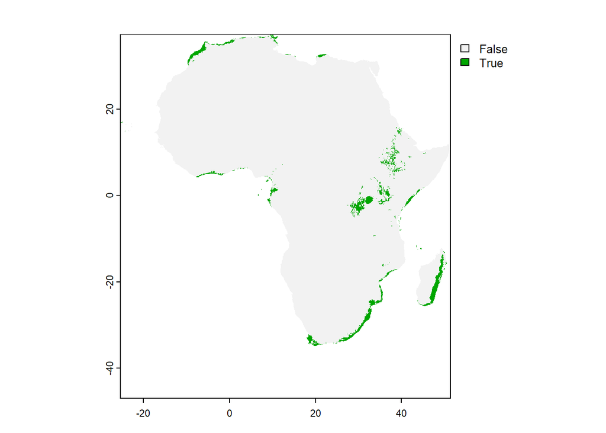

```r
predict_maxent_africa = terra::rast("raster_projections/maxent_projection_africa.tif")
predict_maxent_africa.woSA = terra::rast("raster_projections/maxent_projection_africa.woSA.tif")

predict_maxent_africa_thresh0.75 = predict_maxent_africa > 0.75
terra::plot(predict_maxent_africa_thresh0.75)
```

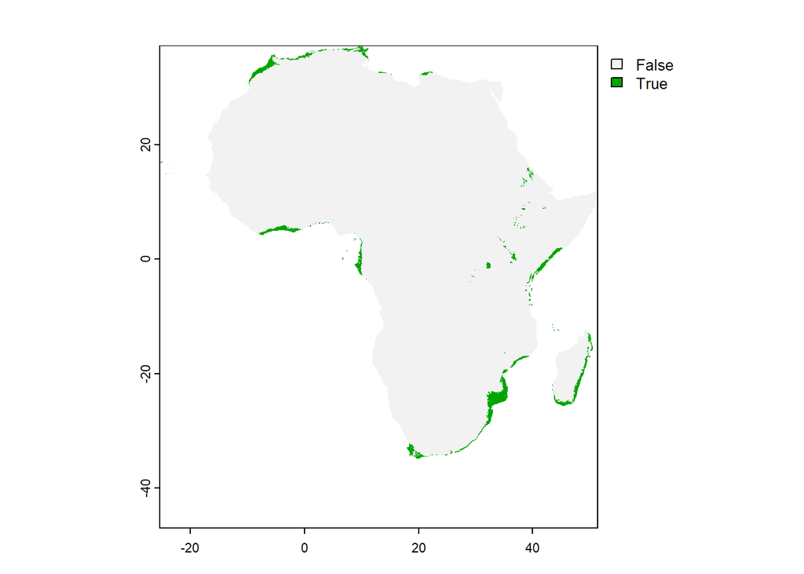

```r
predict_maxent_africa.woSA_thresh0.75 = predict_maxent_africa.woSA > 0.75
terra::plot(predict_maxent_africa.woSA_thresh0.75)
```

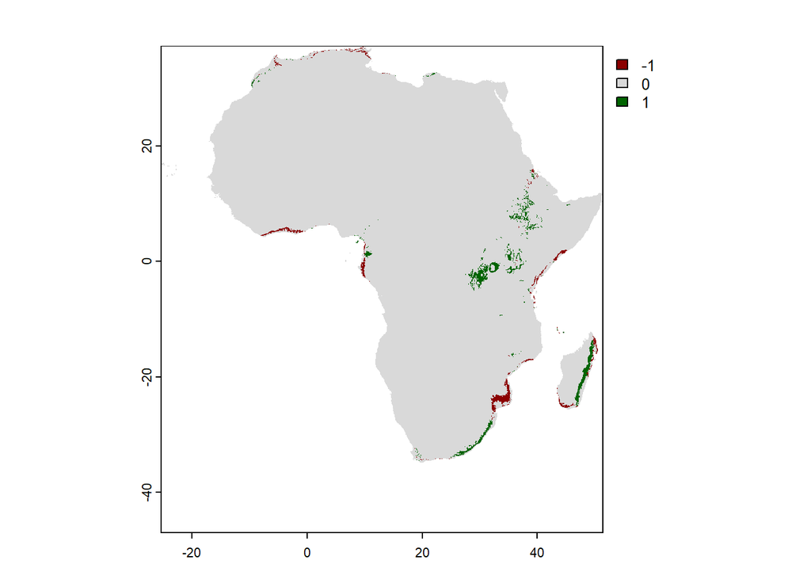

```r
# get the difference between the two rasters
diff_raster = predict_maxent_africa_thresh0.75 - predict_maxent_africa.woSA_thresh0.75
terra::plot(diff_raster, col = c("darkred", "grey85", "darkgreen"))
```

```r
# calculate km area difference
area_raster = terra::cellSize(diff_raster, unit = "km")
total_area_diff_km2 = terra::global(area_raster * (diff_raster != 0), sum, na.rm = TRUE)$sum
total_area_diff_km2
```

```
## [1] 550754.1
```

```r
# if you want to rather use ggplot, first convert the raster to a dataframe
diff_df = as.data.frame(diff_raster, xy = TRUE, na.rm = TRUE)
head(diff_df)
```

```
##            x       y maxent
## 837 9.520833 37.3125      0
## 838 9.562500 37.3125      0
## 839 9.604167 37.3125      0
## 840 9.645833 37.3125      0
## 841 9.687500 37.3125      0
## 842 9.729167 37.3125      0
```

[output not shown]

```
## Scale on map varies by more than 10%, scale bar may be inaccurate
```

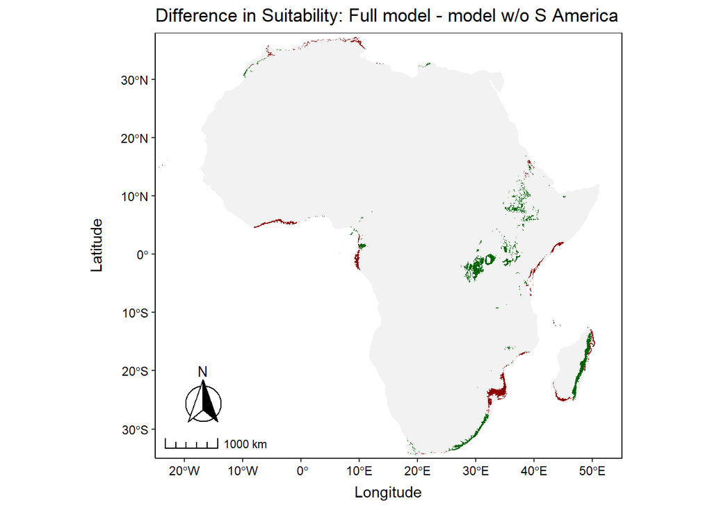

```r
diffafrica.map = ggplot(diff_df) +
  geom_tile(aes(x = x, y = y, fill = factor(maxent))) +
  scale_fill_manual(
    values = c("1" = "darkgreen", "0" = "grey95", "-1" = "darkred"),
    name = "Difference",
    labels = c("-1" = "Decrease", "0" = "No Change", "1" = "Increase")
  ) +
  coord_sf(expand = FALSE) +
  labs(
    title = "Difference in Suitability: Full model - model w/o S America",
    x = "Longitude",
    y = "Latitude"
  ) +
  # Crops map to just the geographic extent of Africa
  coord_sf(
    xlim = c(-25, 55),
    ylim = c(-35, 38),
    crs = 4326,
    expand = FALSE
  ) +
  # Create title for the legend
  theme(legend.position = "right") +
  # Add scale bar to bottom-right of map
 ggspatial::annotation_scale(
    location = "bl",          # 'bl' = bottom left
    style = "ticks",
    width_hint = 0.2
  ) +
  # Add north arrow
  ggspatial::annotation_north_arrow(
    location = "bl",
    which_north = "true",
    pad_x = unit(0.175, "in"),
    pad_y = unit(0.3, "in"),
    style = ggspatial::north_arrow_fancy_orienteering
  ) +
  # Change appearance of the legend
  guides(
    fill = guide_colorbar(ticks = FALSE)
  ) ;diffafrica.map
```

```r
# ggsave("figures/africa_diff.png", plot = diffafrica.map, width = 6, height = 6, dpi = 350)
```

In the above plot, the green areas show where the full model (including South American points) predicted suitable areas (> 0.75) that the model without those points did not, while the red areas show the converse. Grey areas denote no difference between the models.

Let’s use the South American points now to validate our latest MaxEnt model. First, we need to create objects that contain presence and background points for South America, and a raster layer with our predictor variables for the continent.

```r
# Since we already had these presence and background points in our original datasets, let's create subsets that contain just those South American points

presPoints.SAm = presPoints %>%
  dplyr::filter(decimalLatitude >= -56 & decimalLatitude <= 12 &
           decimalLongitude >= -81 & decimalLongitude <= -34)

backPoints.SAm = backPoints %>%
  dplyr::filter(decimalLatitude >= -56 & decimalLatitude <= 12 &
           decimalLongitude >= -81 & decimalLongitude <= -34)

# plot on a world map to confirm
world_map = rnaturalearth::ne_countries(
  scale = "medium",
  returnclass = "sf"
)

# Plot GPS points on world map to check our locality data is correct
ggplot() +
  # Add raster layer of world map
  geom_sf(data = world_map, alpha = 0.5) +
  # Add GPS points
  geom_point(
    data = backPoints.SAm,
    size = 0.2, colour = "darkred",
    aes(x = decimalLongitude, y = decimalLatitude)
  )  +
  geom_point(
    data = presPoints.SAm,
    size = 1, colour = "forestgreen",
    aes(x = decimalLongitude, y = decimalLatitude)
  )  +
  # Set world map CRS
  coord_sf(
    crs = 4326,
    ylim = c(-58, 90),  # Clip below -52 degrees latitude
    expand = FALSE
  ) +
  xlab("Longitude") +
  ylab("Latitude")

# Now let's crop our predictor raster to South America

# read in our predictors again
reduced_preds = terra::rast("data/reduced_preds.tif")

southAmerica_ext = rnaturalearth::ne_countries(scale = "medium",
                                           returnclass = "sf") %>%
  dplyr::filter(continent %in% c("South America"))

southAmerica_ext = sf::st_set_crs(southAmerica_ext, 4326)

# Mask reduced set of WORLDCLIM layers to the extent of South America
southAmerica_map = raster::crop(reduced_preds, southAmerica_ext)

# Get MaxEnt prediction for South America
predict_maxent_SAm = terra::predict(maxentModel.woSA, southAmerica_map)
predict_maxent_SAm = terra::mask(predict_maxent_SAm, southAmerica_ext)
terra::plot(predict_maxent_SAm)
```

Now we need to extract the MaxEnt suitability score at each presence and background point in South America

```r
prespoints.vect = terra::vect(
  presPoints.SAm,
  geom = c("decimalLongitude", "decimalLatitude"),
  crs = "EPSG:4326"
)

backpoints.vect = terra::vect(
  backPoints.SAm,
  geom = c("decimalLongitude", "decimalLatitude"),
  crs = "EPSG:4326"
)

##############################################################
# Extract MaxEnt suitability scores at each PRESENCE GPS point
##############################################################

maxent_pres_scores = terra::extract(
      x = predict_maxent_SAm, # prediction raster of South America
      y = prespoints.vect,
      xy = TRUE,
      na.rm = TRUE
    ) %>%
    # Clean df
    dplyr::select(
      lat = y,
      lon = x,
      suit_score = 2 # assign the name of the second column ("median") to "suit_score"
    ) %>%
    tidyr::drop_na(suit_score) %>%
    dplyr::mutate(pres = 1)

##############################################################
# Extract MaxEnt suitability scores at each BACKGROUND GPS point
##############################################################

maxent_background_scores = terra::extract(
      x = predict_maxent_SAm,
      y = backpoints.vect,
      xy = TRUE,
      na.rm = TRUE
    ) %>%
    # Clean df
    dplyr::select(
      lat = y,
      lon = x,
      suit_score = 2
    ) %>%
    tidyr::drop_na(suit_score) %>%
    dplyr::mutate(pres = 0)

# Combine dataframes
clim_data.SAm = dplyr::bind_rows(maxent_pres_scores, maxent_background_scores)
```

Now that we have predicted MaxEnt scores for each presence and background point in South America, we can run a GLM to see whether the presence of ACP can be reliably predicted given a suitability score generated by the model we built (which excluded South American points). In other words, can the model we created distinguish between presence and background points for ACP?

```r
#############################################################
# Fit statistical model
##############################################################

mod.SAm = glm(pres ~ suit_score, data = clim_data.SAm, family = binomial(link = "logit"))

print(summary(mod.SAm))

# get the beta coefficient
beta_original = coef(mod.SAm)["suit_score"]
beta_per_1percent = beta_original * 0.01
odds_ratio_1percent = exp(beta_per_1percent)
cat("Odds ratio for a 1% increase:", odds_ratio_1percent)

# The value of 1.005653 means that the odds of recording the presence of ACP increases by a factor of 1.005653 with a 1% increase in MaxEnt suitability score.

# check model fit
DHARMa::simulateResiduals(fittedModel = mod.SAm, plot = TRUE)

car::Anova(mod.SAm, test = "LR", type = "II")
# the LR p-value here is not significant

##############################################################
# Plot statistical model
##############################################################

# Extract model predictions
preds = ggeffects::ggpredict(mod.SAm, terms = c("suit_score [0:1 by = 0.01]")) %>%
    as.data.frame() %>%
    dplyr::rename(suit_score = x)

clim_data_presences = dplyr::filter(clim_data.SAm, pres == 1)
clim_data_absences = dplyr::filter(clim_data.SAm, pres == 0)

###############################
# Sensitivity score
###############################

# find the optimal threshold, based on the model
e.SAm = evaluate(p = presPoints.SAm, a = backPoints.SAm, model = maxentModel.woSA)

# View various thresholds
thresholds.SAm = dismo::threshold(e.SAm)
print(thresholds.SAm)

# Define a threshold
threshold.SAm = 0.43
predicted_presence.SAm = ifelse(clim_data.SAm$suit_score >= threshold.SAm, 1, 0)

# Create confusion matrix
conf_matrix.SAm = table(Predicted = predicted_presence.SAm, Observed = clim_data.SAm$pres)
print(conf_matrix.SAm)

# Extract TP and FN
TP.SAm = conf_matrix.SAm["1", "1"]
FN.SAm = conf_matrix.SAm["0", "1"]

# Calculate sensitivity
sensitivity.SAm = TP.SAm / (TP.SAm + FN.SAm)
cat("Sensitivity:", sensitivity.SAm, "\n")

# Plot model predictions
prob_curve_SAm = preds %>%
    ggplot2::ggplot(data = ., aes(x = suit_score, y = predicted)) +
    geom_rug(data = clim_data_presences, aes(x= suit_score, y = pres), sides = "t") +
    geom_rug(data = clim_data_absences, aes(x= suit_score, y = pres), sides = "b") +
    geom_line() +
    geom_ribbon(aes(ymin = conf.low, ymax = conf.high), alpha = 0.1, fill = "steelblue") +
    labs(
      title = "South America",
      subtitle = paste0("Sensitivity = ", round(sensitivity.SAm, 2)),
      x = "MaxEnt suitability score",
      y = "Probability of being recorded"
    ); prob_curve_SAm
```

```r
gridExtra::grid.arrange(prob_curve.africa, prob_curve_SAm, prob_curve.NR, nrow = 1)
```